# DESeqAnalysis

### HOX gene exp plots

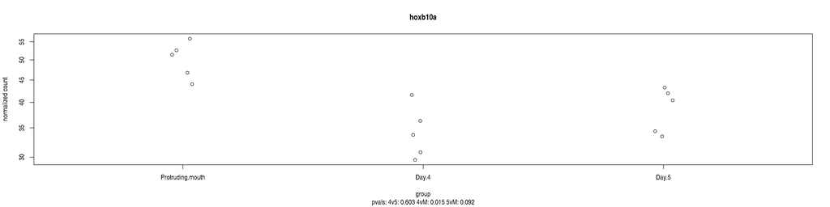

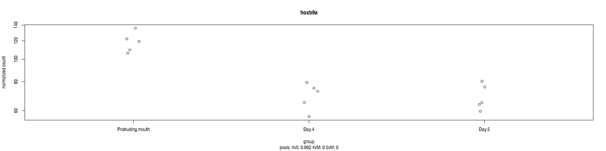

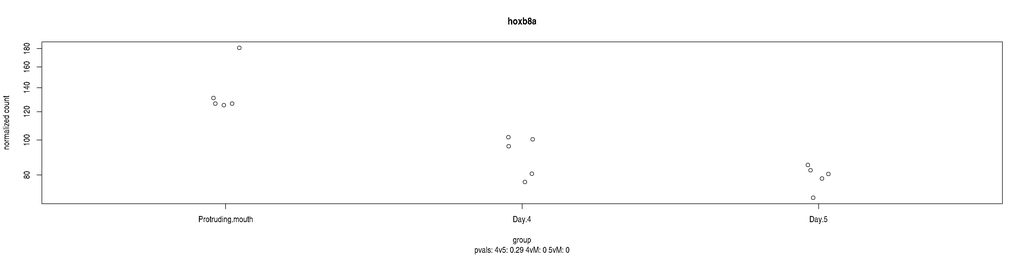

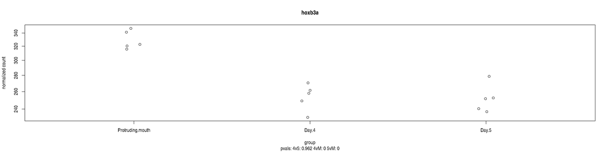

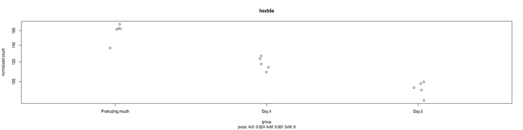

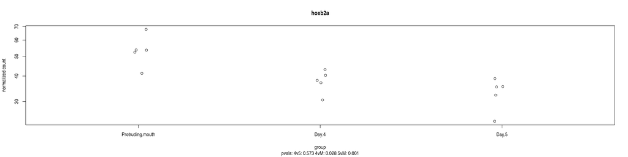

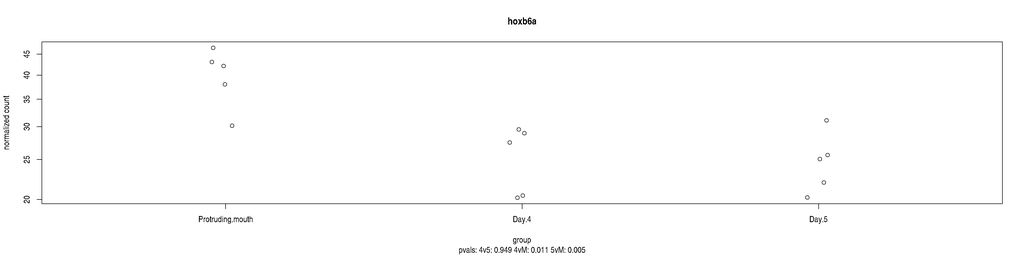

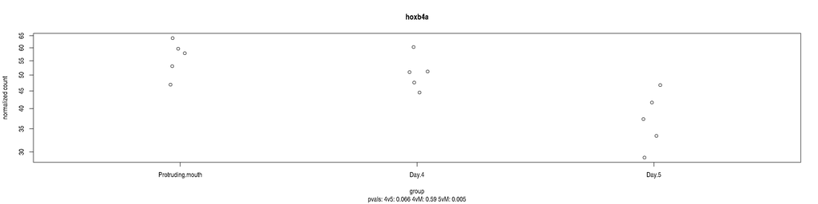

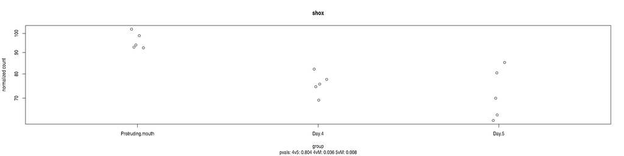

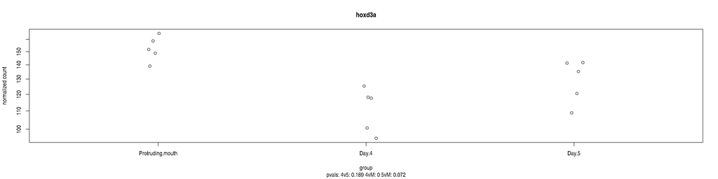

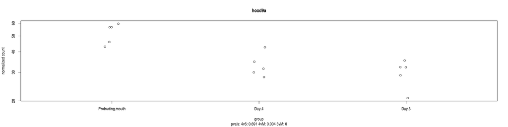

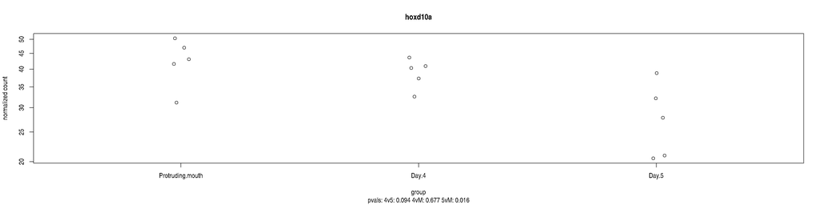

[24 more figures not shown]

```r
select <- grep(rowData(ntd)$SYMBOL,pattern="hox")
# get pvals for comparisons across each other
sig_4v5= (res4v5[select,]$padj < 0.05)
sig_4vM= (res4vM[select,]$padj < 0.05)
sig_5vM= (res5vM[select,]$padj < 0.05)
df_padj_vals = do.call(cbind, list(res4v5[select,]$padj,
                     res4vM[select,]$padj,
                     res5vM[select,]$padj))
# remove
remove_vals = -which(is.na(rowSums(df_padj_vals)))
select=select[remove_vals]
df_padj_vals=df_padj_vals[remove_vals,]
sig_4v5= sig_4v5[remove_vals]
sig_4vM= sig_4vM[remove_vals]
sig_5vM= sig_5vM[remove_vals]

(for (i in 1:length(select)){
  if (sig_4v5[i]==T | sig_4vM[i]==T | sig_5vM[i]==T){
    pvals=paste("pvals: 4v5:", round(df_padj_vals[i,1],3),
                "4vM:", round(df_padj_vals[i,2],3),
                "5vM:", round(df_padj_vals[i,3],3))
    plotCounts(dds, gene=select[i], intgroup="stageName", main = "", sub=pvals)
    title(rowData(dds)[rownames(dds[select[i],]),]$SYMBOL)
  }
})
```

Plotting out the HOX genes individually with their padj values we do see that we do get a better view that although we do not have significant pvalues for most hox genes when comparing the last two time points, HOX genes seem to trend downwards with respect to time for the three time points available.

```r
pdf("outputs/hox_gene_plots.pdf")
par(mfrow = c(2,1))
for (i in 1:length(select)){
  if (sig_4v5[i]==T | sig_4vM[i]==T | sig_5vM[i]==T){
    pvals=paste("pvals: 4v5:", round(df_padj_vals[i,1],3),
                "4vM:", round(df_padj_vals[i,2],3),
                "5vM:", round(df_padj_vals[i,3],3))
    plotCounts(dds, gene=select[i], intgroup="stageName", main = "", sub=pvals)
    title(rowData(dds)[rownames(dds[select[i],]),]$SYMBOL)
  }
}
dev.off()
```

```
## PNG
##   2
```

## Pathway Analysis

```r
c2.cp7.gmt=msigdbr(species = "Danio rerio", category = "C2", subcategory = "CP:REACTOME")
msigdbr_list = split(x = c2.cp7.gmt$gene_symbol, f = c2.cp7.gmt$gs_name)

map= cbind(c2.cp7.gmt$ensembl_gene, c2.cp7.gmt$gene_symbol) %>% as.data.frame()
colnames(map) = c("ensembl_gene", "gene_symbol")
# here we clean up the names more so we can run fgsea
genes4v5 <- as.data.frame(res4v5)%>%
  mutate(ensembl_gene = rownames(.)) %>%
  join(., map, by = c("ensembl_gene"),
                 type="inner") %>%
  dplyr::select(gene_symbol, stat) %>%
  stats::na.omit() %>%
  dplyr::distinct() %>%
  dplyr::group_by(gene_symbol) %>%
  dplyr::summarize(stat=mean(stat)) %>%
  with(., setNames(stat, gene_symbol))

genes4vM <- as.data.frame(res4vM)%>%
  mutate(ensembl_gene = rownames(.)) %>%
  join(., map, by = c("ensembl_gene"),
                 type="inner") %>%
  dplyr::select(gene_symbol, stat) %>%
  stats::na.omit() %>%
  dplyr::distinct() %>%
  dplyr::group_by(gene_symbol) %>%
  dplyr::summarize(stat=mean(stat)) %>%
  with(., setNames(stat, gene_symbol))

genes5vM <- as.data.frame(res5vM)%>%
  mutate(ensembl_gene = rownames(.)) %>%
  join(., map, by = c("ensembl_gene"),
                 type="inner") %>%
  dplyr::select(gene_symbol, stat) %>%
  stats::na.omit() %>%
  dplyr::distinct() %>%
  dplyr::group_by(gene_symbol) %>%
  dplyr::summarize(stat=mean(stat)) %>%
  with(., setNames(stat, gene_symbol))


out4vM = fgsea(pathways=msigdbr_list, stats = genes4vM, nperm=1000)
out5vM = fgsea(pathways=msigdbr_list, stats = genes5vM, nperm=1000)
out4v5 = fgsea(pathways=msigdbr_list, stats = genes4v5, nperm=1000)
```

```r
out4vM %>% arrange(., desc(NES)) %>% .[,-c("leadingEdge", "nMoreExtreme")]
```

```
##                                                                  pathway
##    1:                                     REACTOME_BIOLOGICAL_OXIDATIONS
##    2:                    REACTOME_PHASE_I_FUNCTIONALIZATION_OF_COMPOUNDS
##    3:                                     REACTOME_FATTY_ACID_METABOLISM
##    4:                              REACTOME_PEROXISOMAL_LIPID_METABOLISM
##    5:        REACTOME_METABOLISM_OF_WATER_SOLUBLE_VITAMINS_AND_COFACTORS
##   ---
## 1611:                                        REACTOME_HEDGEHOG_OFF_STATE
## 1612: REACTOME_THE_ROLE_OF_GTSE1_IN_G2_M_PROGRESSION_AFTER_G2_CHECKPOINT
## 1613:                                 REACTOME_MITOCHONDRIAL_TRANSLATION
## 1614:                                             REACTOME_MRNA_SPLICING
## 1615:           REACTOME_PROCESSING_OF_CAPPED_INTRON_CONTAINING_PRE_MRNA
##              pval       padj         ES       NES size
##    1: 0.001607717 0.01690639  0.6730760  2.586696  160
##    2: 0.001776199 0.01690639  0.7056560  2.402833   76
##    3: 0.001597444 0.01690639  0.6246230  2.396765  155
##    4: 0.001930502 0.01690639  0.8215494  2.317004   28
##    5: 0.001663894 0.01690639  0.6231233  2.290122  114
##   ---
## 1611: 0.002457002 0.01690639 -0.6590440 -2.569821  111
## 1612: 0.002277904 0.01690639 -0.7232931 -2.687853   76
## 1613: 0.002375297 0.01690639 -0.7054991 -2.699768   92
## 1614: 0.002617801 0.01690639 -0.6764040 -2.835351  179
## 1615: 0.002777778 0.01705746 -0.6703286 -2.903338  229
```

```r
out5vM %>% arrange(.,desc(NES)) %>% .[,-c("leadingEdge", "nMoreExtreme")]
```

```
##                                                                  pathway
##    1:                         REACTOME_EUKARYOTIC_TRANSLATION_ELONGATION
##    2:                REACTOME_CYTOCHROME_P450_ARRANGED_BY_SUBSTRATE_TYPE
##    3:                    REACTOME_PHASE_I_FUNCTIONALIZATION_OF_COMPOUNDS
##    4:                                     REACTOME_BIOLOGICAL_OXIDATIONS
##    5:        REACTOME_COBALAMIN_CBL_VITAMIN_B12_TRANSPORT_AND_METABOLISM
##   ---
## 1611:                   REACTOME_NEGATIVE_REGULATION_OF_NOTCH4_SIGNALING
## 1612:                                REACTOME_HEDGEHOG_LIGAND_BIOGENESIS
## 1613:                 REACTOME_AUF1_HNRNP_D0_BINDS_AND_DESTABILIZES_MRNA
## 1614:                          REACTOME_HOST_INTERACTIONS_OF_HIV_FACTORS
## 1615: REACTOME_THE_ROLE_OF_GTSE1_IN_G2_M_PROGRESSION_AFTER_G2_CHECKPOINT
##              pval       padj         ES       NES size
##    1: 0.002487562 0.01419581  0.6692932  2.456295   86
##    2: 0.002277904 0.01337751  0.7083843  2.354861   48
##    3: 0.002457002 0.01412121  0.6503757  2.349343   77
##    4: 0.002610966 0.01469237  0.5495980  2.245981  161
##    5: 0.002314815 0.01349612  0.8597002  2.233018   17
##   ---
## 1611: 0.001821494 0.01195960 -0.7883863 -2.605934   54
## 1612: 0.001733102 0.01195960 -0.7622982 -2.616040   65
## 1613: 0.001792115 0.01195960 -0.7909484 -2.631139   55
## 1614: 0.001655629 0.01195960 -0.7057418 -2.650356  125
## 1615: 0.001683502 0.01195960 -0.7883926 -2.806176   76
```

```r
out4v5 %>% arrange(.,desc(NES)) %>% .[,-c("leadingEdge", "nMoreExtreme")]
```

```
##                                                                                                                         pathway
##    1:                                                                                REACTOME_EUKARYOTIC_TRANSLATION_ELONGATION
##    2:                                                                REACTOME_RESPONSE_OF_EIF2AK4_GCN2_TO_AMINO_ACID_DEFICIENCY
##    3:                                                                                REACTOME_EUKARYOTIC_TRANSLATION_INITIATION
##    4:                                                                                                  REACTOME_RRNA_PROCESSING
##    5:                                                                                      REACTOME_NONSENSE_MEDIATED_DECAY_NMD
##   ---
## 1611:                                                                                               REACTOME_COLLAGEN_FORMATION
## 1612:                                                     REACTOME_THE_CITRIC_ACID_TCA_CYCLE_AND_RESPIRATORY_ELECTRON_TRANSPORT
## 1613:                                                     REACTOME_ASSEMBLY_OF_COLLAGEN_FIBRILS_AND_OTHER_MULTIMERIC_STRUCTURES
## 1614: REACTOME_RESPIRATORY_ELECTRON_TRANSPORT_ATP_SYNTHESIS_BY_CHEMIOSMOTIC_COUPLING_AND_HEAT_PRODUCTION_BY_UNCOUPLING_PROTEINS
## 1615:                                                                                   REACTOME_RESPIRATORY_ELECTRON_TRANSPORT
##              pval       padj         ES       NES size
##    1: 0.003154574 0.02431863  0.9198568  3.445680   86
##    2: 0.003184713 0.02431863  0.8962886  3.408676   95
##    3: 0.003436426 0.02431863  0.8542991  3.338518  113
##    4: 0.003773585 0.02615596  0.7708608  3.291967  194
##    5: 0.003412969 0.02431863  0.8350874  3.205038  106
##   ---
## 1611: 0.001479290 0.01665120 -0.7389395 -2.529274   78
## 1612: 0.001331558 0.01665120 -0.6595379 -2.531114  174
## 1613: 0.001557632 0.01665120 -0.7788779 -2.537946   54
## 1614: 0.001392758 0.01665120 -0.7023856 -2.568759  125
## 1615: 0.001430615 0.01665120 -0.7367682 -2.622479  102
```

## plots for GSEA

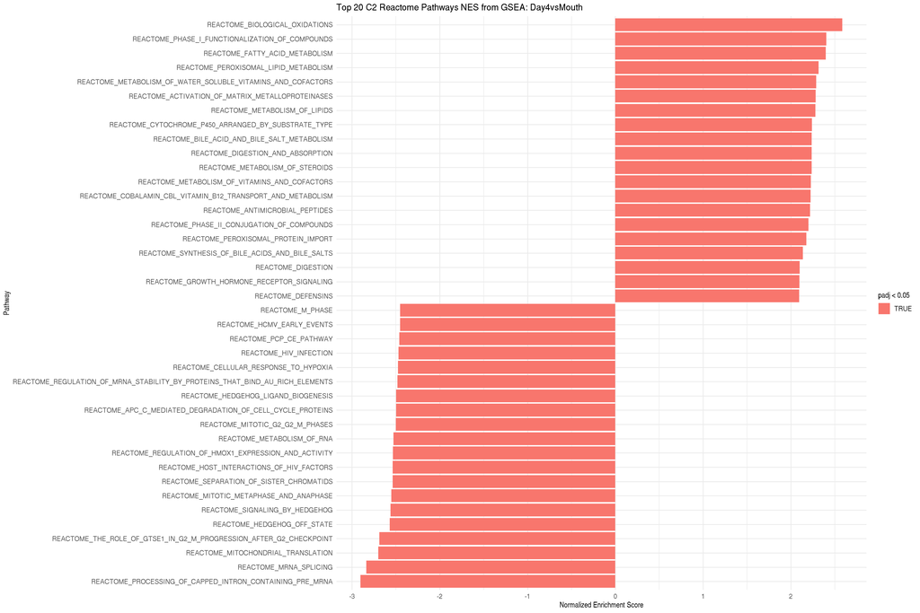

```r
# select the top 20 on both sides
out4vM_f <- slice_max(out4vM, n=20, order_by = NES) %>%
  rbind(., slice_min(out4vM, n = 20, order_by = NES))
ggplot(out4vM_f, aes(reorder(pathway, NES), NES)) +
  geom_col(aes(fill=padj<0.05)) +
  coord_flip() +
  labs(x="Pathway", y="Normalized Enrichment Score",
       title="Top 20 C2 Reactome Pathways NES from GSEA: Day4vsMouth") +
  theme_minimal()

ggsave("outputs/GSEA4vM.pdf", height = 16, width = 8)
```

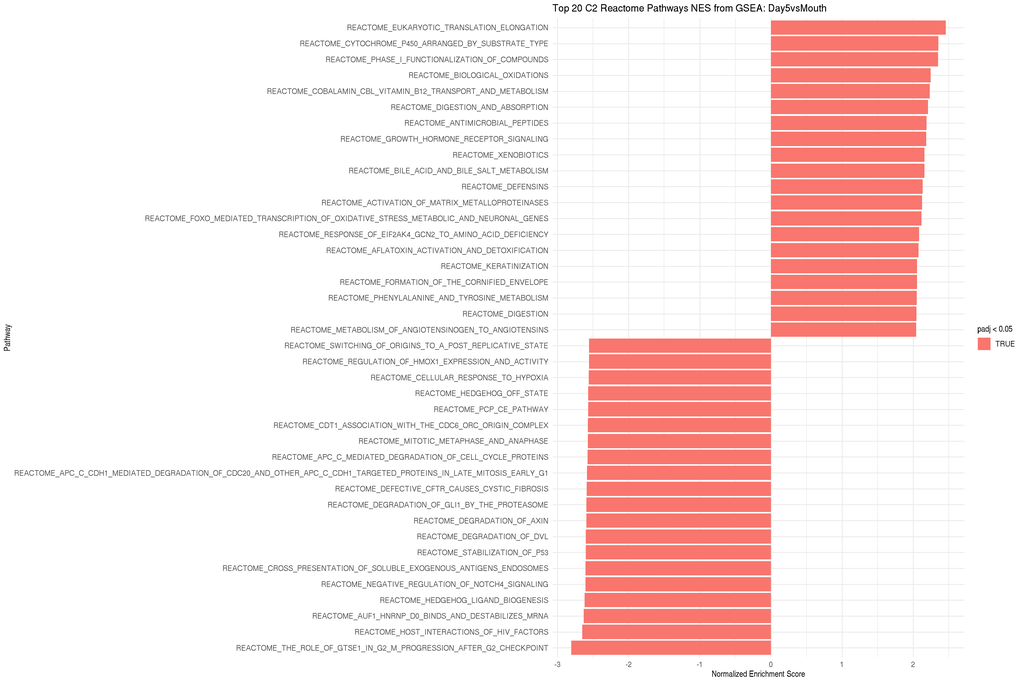

```r
# select the top 20 on both sides
out5vM_f <- slice_max(out5vM, n=20, order_by = NES) %>%
  rbind(., slice_min(out5vM, n = 20, order_by = NES))
ggplot(out5vM_f, aes(reorder(pathway, NES), NES)) +
  geom_col(aes(fill=padj<0.05)) +
  coord_flip() +
  labs(x="Pathway", y="Normalized Enrichment Score",
       title="Top 20 C2 Reactome Pathways NES from GSEA: Day5vsMouth") +
  theme_minimal()

ggsave("outputs/GSEA5vM.pdf", height = 16, width = 8)
```

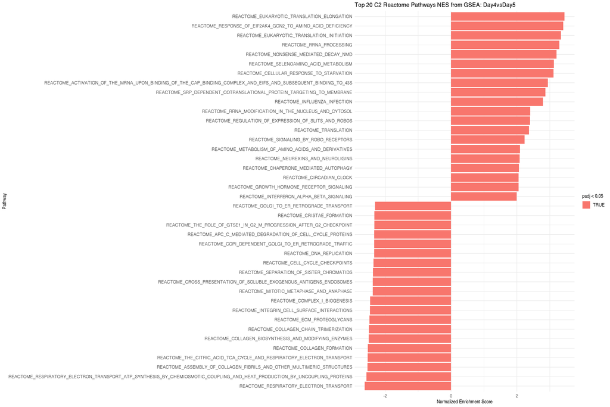

```r
# select the top 20 on both sides
out4v5_f <- slice_max(out4v5, n=20, order_by = NES) %>%
  rbind(., slice_min(out4v5, n = 20, order_by = NES))
ggplot(out4v5_f, aes(reorder(pathway, NES), NES)) +
  geom_col(aes(fill=padj<0.05)) +
  coord_flip() +
  labs(x="Pathway", y="Normalized Enrichment Score",
       title="Top 20 C2 Reactome Pathways NES from GSEA: Day4vsDay5") +
  theme_minimal()

ggsave("outputs/GSEA4v5.pdf", height = 16, width = 8)
```

Some variability in the pathways that were enriched, but we do have decent number of similarities for the 4vM and 5vM contrasts.

```r
out4vM_f$leadingEdge %>% unlist() %>% table() %>% sort()
```

[output not shown]

[output cut: 386 more lines]

```
##               16               16               16               16
##           psma6a            psma8            psmb1            psmb2
##               16               16               16               16
##            psmb3            psmb4            psmb5            psmb6
##               16               16               16               16
##            psmb7           psmc1b            psmc2            psmc3
##               16               16               16               16
##            psmc4            psmc5            psmc6            psmd1
##               16               16               16               16
##           psmd12           psmd13           psmd14            psmd3
##               16               16               16               16
##            psmd6            psmd7            psmd8            psme3
##               16               16               16               16
##             sem1              ubc
##               16               16
```

```r
out5vM_f$leadingEdge %>% unlist() %>% table() %>% sort()
```

[output not shown]

[output cut: 160 more lines]

```
##                20                20                20                20
##             psmb1             psmb2             psmb3             psmb4
##                20                20                20                20
##             psmb5             psmb6             psmb7            psmc1b
##                20                20                20                20
##             psmc2             psmc3             psmc4             psmc5
##                20                20                20                20
##             psmc6             psmd1            psmd10           psmd11a
##                20                20                20                20
##            psmd12            psmd13            psmd14             psmd2
##                20                20                20                20
##             psmd3            psmd4a             psmd6             psmd7
##                20                20                20                20
##             psmd8             psme3              sem1
##                20                20                20
```

```r
out4v5_f$leadingEdge %>% unlist() %>% table() %>% sort()
```

[output not shown]

[output cut: 288 more lines]

```
##               14               14               14               14
##            rps16            rps18            rps19            rps20
##               14               14               14               14
##            rps21            rps23            rps24            rps25
##               14               14               14               14
##            rps26           rps26l          rps27.1           rps27l
##               14               14               14               14
##            rps28            rps29             rps3            rps3a
##               14               14               14               14
##            rps4x             rps5            rps8a             rpsa
##               14               14               14               14
##       zgc:114188            rps14             rps2             rps6
##               14               15               15               15
##             rps7             rps9            uba52           rps27a
##               15               15               15               16
```

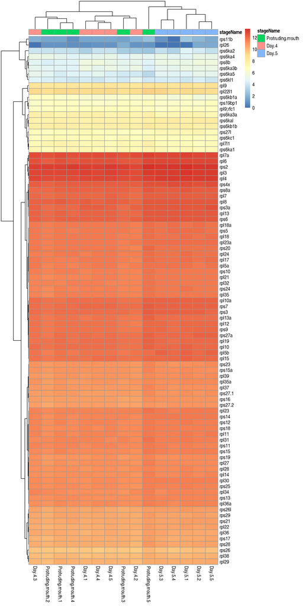

```r
selectr <- grep(rowData(ntd)$SYMBOL,pattern="^rps[0-9]|^rpl[0-9]")
pheatmap(assay(ntd)[selectr,], cluster_rows=TRUE,
         labels_row=grep(rowData(ntd)$SYMBOL,
                         pattern="^rps[0-9]|^rpl[0-9]", value=TRUE),
         cluster_cols=TRUE, annotation_col=df)
```